# Risk Factor Analysis

## Outcome Variable

**Outcome Variable:** wasted

## Predictor Variables

**Intervention Variable:** hdlvry

**Adjustment Set:**

- arm
- sex
- W_mage
- meducyrs
- feducyrs
- hhwealth_quart
- single
- W_nrooms
- brthmon
- W_parity
- impsan
- delta_W_mage
- delta_meducyrs
- delta_feducyrs
- delta_hhwealth_quart
- delta_single
- delta_W_nrooms
- delta_brthmon
- delta_W_parity
- delta_impsan

## Stratifying Variables

The analysis was stratified on these variable(s):

- agecat
- studyid
- country

## Data Summary

| agecat | studyid | country | hdlvry | wasted | n_cell | n |
| --- | --- | --- | --- | --- | --- | --- |
| Birth | CMC-V-BCS-2002 | INDIA | 0 | 0 | 75 | 86 |
| Birth | CMC-V-BCS-2002 | INDIA | 0 | 1 | 11 | 86 |
| Birth | CMC-V-BCS-2002 | INDIA | 1 | 0 | 0 | 86 |
| Birth | CMC-V-BCS-2002 | INDIA | 1 | 1 | 0 | 86 |
| Birth | COHORTS | INDIA | 0 | 0 | 2284 | 4389 |
| Birth | COHORTS | INDIA | 0 | 1 | 479 | 4389 |
| Birth | COHORTS | INDIA | 1 | 0 | 1344 | 4389 |
| Birth | COHORTS | INDIA | 1 | 1 | 282 | 4389 |
| Birth | EE | PAKISTAN | 0 | 0 | 106 | 175 |
| Birth | EE | PAKISTAN | 0 | 1 | 14 | 175 |
| Birth | EE | PAKISTAN | 1 | 0 | 47 | 175 |
| Birth | EE | PAKISTAN | 1 | 1 | 8 | 175 |
| Birth | GMS-Nepal | NEPAL | 0 | 0 | 109 | 596 |
| Birth | GMS-Nepal | NEPAL | 0 | 1 | 34 | 596 |
| Birth | GMS-Nepal | NEPAL | 1 | 0 | 364 | 596 |
| Birth | GMS-Nepal | NEPAL | 1 | 1 | 89 | 596 |
| Birth | IRC | INDIA | 0 | 0 | 249 | 343 |
| Birth | IRC | INDIA | 0 | 1 | 88 | 343 |
| Birth | IRC | INDIA | 1 | 0 | 2 | 343 |
| Birth | IRC | INDIA | 1 | 1 | 4 | 343 |
| Birth | JiVitA-3 | BANGLADESH | 0 | 0 | 25 | 292 |
| Birth | JiVitA-3 | BANGLADESH | 0 | 1 | 2 | 292 |
| Birth | JiVitA-3 | BANGLADESH | 1 | 0 | 232 | 292 |
| Birth | JiVitA-3 | BANGLADESH | 1 | 1 | 33 | 292 |
| Birth | JiVitA-4 | BANGLADESH | 0 | 0 | 445 | 2384 |
| Birth | JiVitA-4 | BANGLADESH | 0 | 1 | 55 | 2384 |
| Birth | JiVitA-4 | BANGLADESH | 1 | 0 | 1700 | 2384 |
| Birth | JiVitA-4 | BANGLADESH | 1 | 1 | 184 | 2384 |
| Birth | NIH-Crypto | BANGLADESH | 0 | 0 | 426 | 707 |
| Birth | NIH-Crypto | BANGLADESH | 0 | 1 | 122 | 707 |

[output cut: 98 more lines]

The following strata were considered:

- agecat: 24 months, studyid: CMC-V-BCS-2002, country: INDIA
- agecat: 24 months, studyid: COHORTS, country: INDIA
- agecat: 24 months, studyid: EE, country: PAKISTAN
- agecat: 24 months, studyid: GMS-Nepal, country: NEPAL
- agecat: 24 months, studyid: IRC, country: INDIA
- agecat: 24 months, studyid: JiVitA-3, country: BANGLADESH
- agecat: 24 months, studyid: JiVitA-4, country: BANGLADESH
- agecat: 24 months, studyid: NIH-Crypto, country: BANGLADESH
- agecat: 24 months, studyid: PROVIDE, country: BANGLADESH
- agecat: 24 months, studyid: TanzaniaChild2, country: TANZANIA, UNITED REPUBLIC OF
- agecat: 6 months, studyid: CMC-V-BCS-2002, country: INDIA
- agecat: 6 months, studyid: COHORTS, country: INDIA
- agecat: 6 months, studyid: EE, country: PAKISTAN
- agecat: 6 months, studyid: GMS-Nepal, country: NEPAL
- agecat: 6 months, studyid: IRC, country: INDIA
- agecat: 6 months, studyid: JiVitA-3, country: BANGLADESH
- agecat: 6 months, studyid: JiVitA-4, country: BANGLADESH
- agecat: 6 months, studyid: NIH-Crypto, country: BANGLADESH
- agecat: 6 months, studyid: PROVIDE, country: BANGLADESH
- agecat: 6 months, studyid: SAS-CompFeed, country: INDIA
- agecat: 6 months, studyid: SAS-FoodSuppl, country: INDIA
- agecat: 6 months, studyid: TanzaniaChild2, country: TANZANIA, UNITED REPUBLIC OF
- agecat: Birth, studyid: CMC-V-BCS-2002, country: INDIA
- agecat: Birth, studyid: COHORTS, country: INDIA
- agecat: Birth, studyid: EE, country: PAKISTAN
- agecat: Birth, studyid: GMS-Nepal, country: NEPAL
- agecat: Birth, studyid: IRC, country: INDIA
- agecat: Birth, studyid: JiVitA-3, country: BANGLADESH
- agecat: Birth, studyid: JiVitA-4, country: BANGLADESH
- agecat: Birth, studyid: NIH-Crypto, country: BANGLADESH
- agecat: Birth, studyid: PROVIDE, country: BANGLADESH
- agecat: Birth, studyid: SAS-CompFeed, country: INDIA

### Dropped Strata

Some strata were dropped due to rare outcomes:

- agecat: Birth, studyid: CMC-V-BCS-2002, country: INDIA
- agecat: Birth, studyid: IRC, country: INDIA
- agecat: Birth, studyid: JiVitA-3, country: BANGLADESH
- agecat: 6 months, studyid: CMC-V-BCS-2002, country: INDIA
- agecat: 6 months, studyid: IRC, country: INDIA
- agecat: 6 months, studyid: JiVitA-3, country: BANGLADESH
- agecat: 6 months, studyid: PROVIDE, country: BANGLADESH
- agecat: 6 months, studyid: TanzaniaChild2, country: TANZANIA, UNITED REPUBLIC OF
- agecat: 24 months, studyid: CMC-V-BCS-2002, country: INDIA
- agecat: 24 months, studyid: IRC, country: INDIA
- agecat: 24 months, studyid: TanzaniaChild2, country: TANZANIA, UNITED REPUBLIC OF

## Methods Detail

We’re interested in the causal parameters $E[Y_a]$ for all values of $a \in \mathcal{A}$. These parameters represent the mean outcome if, possibly contrary to fact, we intervened to set all units to have $A=a$. Under the randomization and positivity assumptions, these are identified by the statistical parameters $\psi_a=E_W[E_{Y|A,W}(Y|A=a,W)]$. In addition, we’re interested in the mean of $Y$, $E[Y]$ under no intervention (the observed mean). We will estimate these parameters by using SuperLearner to fit the relevant likelihood factors – $E_{Y|A,W}(Y|A=a,W)$ and $p(A=a|W)$, and then updating our likelihood fit using a joint TMLE.

For unadjusted analyses ($W=\{\}$), initial likelihoods were estimated using Lrnr_glm to estimate the simple $E(Y|A)$ and Lrnr_mean to estimate $p(A)$. For adjusted analyses, a small library containing Lrnr_glmnet, Lrnr_xgboost, and Lrnr_mean was used.

Having estimated these parameters, we will then use the delta method to estimate relative risks and attributable risks relative to a prespecified baseline level of $A$.

# Results Detail

## Results Plots

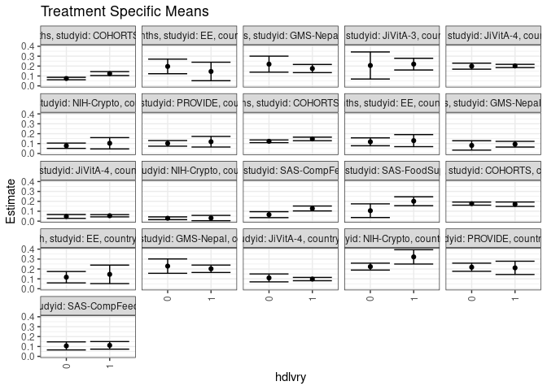

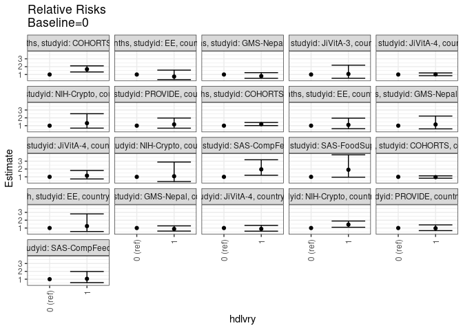

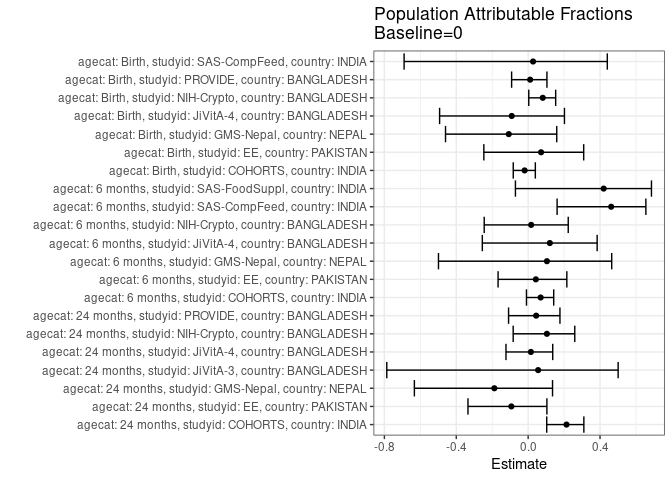

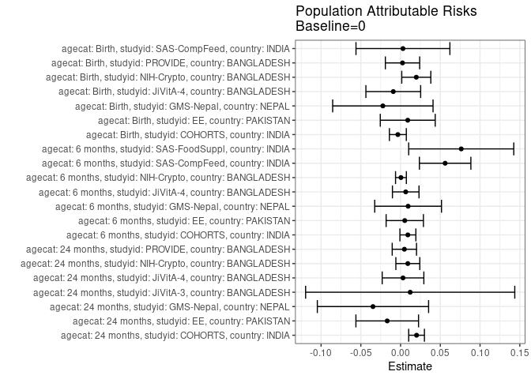

## Results Table

### Parameter: TSM

| agecat | studyid | country | intervention_level | baseline_level | estimate | ci_lower | ci_upper |
| --- | --- | --- | --- | --- | --- | --- | --- |
| Birth | COHORTS | INDIA | 0 | NA | 0.1767910 | 0.1611172 | 0.1924649 |
| Birth | COHORTS | INDIA | 1 | NA | 0.1708485 | 0.1487573 | 0.1929398 |
| Birth | EE | PAKISTAN | 0 | NA | 0.1166667 | 0.0590647 | 0.1742687 |
| Birth | EE | PAKISTAN | 1 | NA | 0.1454545 | 0.0520125 | 0.2388966 |
| Birth | GMS-Nepal | NEPAL | 0 | NA | 0.2286535 | 0.1561952 | 0.3011118 |
| Birth | GMS-Nepal | NEPAL | 1 | NA | 0.2018230 | 0.1643422 | 0.2393037 |
| Birth | JiVitA-4 | BANGLADESH | 0 | NA | 0.1094195 | 0.0694488 | 0.1493903 |
| Birth | JiVitA-4 | BANGLADESH | 1 | NA | 0.0977588 | 0.0811117 | 0.1144059 |
| Birth | NIH-Crypto | BANGLADESH | 0 | NA | 0.2235049 | 0.1886012 | 0.2584087 |
| Birth | NIH-Crypto | BANGLADESH | 1 | NA | 0.3217856 | 0.2495368 | 0.3940343 |
| Birth | PROVIDE | BANGLADESH | 0 | NA | 0.2174787 | 0.1764608 | 0.2584965 |
| Birth | PROVIDE | BANGLADESH | 1 | NA | 0.2110235 | 0.1438683 | 0.2781788 |
| Birth | SAS-CompFeed | INDIA | 0 | NA | 0.1056888 | 0.0648967 | 0.1464809 |
| Birth | SAS-CompFeed | INDIA | 1 | NA | 0.1112984 | 0.0727912 | 0.1498055 |
| 6 months | COHORTS | INDIA | 0 | NA | 0.1232985 | 0.1096933 | 0.1369037 |
| 6 months | COHORTS | INDIA | 1 | NA | 0.1471902 | 0.1292400 | 0.1651403 |
| 6 months | EE | PAKISTAN | 0 | NA | 0.1180358 | 0.0780243 | 0.1580473 |
| 6 months | EE | PAKISTAN | 1 | NA | 0.1298491 | 0.0689401 | 0.1907581 |
| 6 months | GMS-Nepal | NEPAL | 0 | NA | 0.0814169 | 0.0339137 | 0.1289202 |
| 6 months | GMS-Nepal | NEPAL | 1 | NA | 0.0937408 | 0.0648997 | 0.1225820 |
| 6 months | JiVitA-4 | BANGLADESH | 0 | NA | 0.0472058 | 0.0275985 | 0.0668131 |
| 6 months | JiVitA-4 | BANGLADESH | 1 | NA | 0.0543774 | 0.0431653 | 0.0655895 |
| 6 months | NIH-Crypto | BANGLADESH | 0 | NA | 0.0288809 | 0.0149256 | 0.0428361 |
| 6 months | NIH-Crypto | BANGLADESH | 1 | NA | 0.0310559 | 0.0042420 | 0.0578698 |
| 6 months | SAS-CompFeed | INDIA | 0 | NA | 0.0652664 | 0.0351566 | 0.0953763 |
| 6 months | SAS-CompFeed | INDIA | 1 | NA | 0.1276495 | 0.1029424 | 0.1523566 |
| 6 months | SAS-FoodSuppl | INDIA | 0 | NA | 0.1052632 | 0.0361757 | 0.1743506 |
| 6 months | SAS-FoodSuppl | INDIA | 1 | NA | 0.2006579 | 0.1555785 | 0.2457373 |
| 24 months | COHORTS | INDIA | 0 | NA | 0.0741375 | 0.0617236 | 0.0865514 |
| 24 months | COHORTS | INDIA | 1 | NA | 0.1238089 | 0.1040340 | 0.1435838 |
| 24 months | EE | PAKISTAN | 0 | NA | 0.1964286 | 0.1226283 | 0.2702288 |
| 24 months | EE | PAKISTAN | 1 | NA | 0.1454545 | 0.0519996 | 0.2389095 |
| 24 months | GMS-Nepal | NEPAL | 0 | NA | 0.2193359 | 0.1383317 | 0.3003401 |
| 24 months | GMS-Nepal | NEPAL | 1 | NA | 0.1749901 | 0.1337281 | 0.2162520 |
| 24 months | JiVitA-3 | BANGLADESH | 0 | NA | 0.2058824 | 0.0691344 | 0.3426304 |
| 24 months | JiVitA-3 | BANGLADESH | 1 | NA | 0.2196078 | 0.1605007 | 0.2787149 |
| 24 months | JiVitA-4 | BANGLADESH | 0 | NA | 0.1990222 | 0.1685905 | 0.2294539 |
| 24 months | JiVitA-4 | BANGLADESH | 1 | NA | 0.2009709 | 0.1843640 | 0.2175778 |
| 24 months | NIH-Crypto | BANGLADESH | 0 | NA | 0.0784192 | 0.0515551 | 0.1052833 |
| 24 months | NIH-Crypto | BANGLADESH | 1 | NA | 0.1034295 | 0.0463477 | 0.1605114 |
| 24 months | PROVIDE | BANGLADESH | 0 | NA | 0.1023032 | 0.0738161 | 0.1307904 |
| 24 months | PROVIDE | BANGLADESH | 1 | NA | 0.1188301 | 0.0653321 | 0.1723281 |

### Parameter: E(Y)

| agecat | studyid | country | intervention_level | baseline_level | estimate | ci_lower | ci_upper |
| --- | --- | --- | --- | --- | --- | --- | --- |
| Birth | COHORTS | INDIA | NA | NA | 0.1733880 | 0.1621865 | 0.1845895 |
| Birth | EE | PAKISTAN | NA | NA | 0.1257143 | 0.0764545 | 0.1749741 |
| Birth | GMS-Nepal | NEPAL | NA | NA | 0.2063758 | 0.1738576 | 0.2388940 |
| Birth | JiVitA-4 | BANGLADESH | NA | NA | 0.1002517 | 0.0845941 | 0.1159092 |
| Birth | NIH-Crypto | BANGLADESH | NA | NA | 0.2432815 | 0.2116319 | 0.2749310 |
| Birth | PROVIDE | BANGLADESH | NA | NA | 0.2199248 | 0.1846953 | 0.2551543 |
| Birth | SAS-CompFeed | INDIA | NA | NA | 0.1086729 | 0.0774328 | 0.1399131 |
| 6 months | COHORTS | INDIA | NA | NA | 0.1325096 | 0.1228094 | 0.1422097 |
| 6 months | EE | PAKISTAN | NA | NA | 0.1233244 | 0.0899110 | 0.1567378 |
| 6 months | GMS-Nepal | NEPAL | NA | NA | 0.0909091 | 0.0663648 | 0.1154534 |
| 6 months | JiVitA-4 | BANGLADESH | NA | NA | 0.0536863 | 0.0440214 | 0.0633512 |
| 6 months | NIH-Crypto | BANGLADESH | NA | NA | 0.0293706 | 0.0169860 | 0.0417552 |
| 6 months | SAS-CompFeed | INDIA | NA | NA | 0.1213235 | 0.0974115 | 0.1452356 |
| 6 months | SAS-FoodSuppl | INDIA | NA | NA | 0.1815789 | 0.1427684 | 0.2203895 |
| 24 months | COHORTS | INDIA | NA | NA | 0.0942542 | 0.0846183 | 0.1038901 |
| 24 months | EE | PAKISTAN | NA | NA | 0.1796407 | 0.1212426 | 0.2380388 |
| 24 months | GMS-Nepal | NEPAL | NA | NA | 0.1846154 | 0.1489263 | 0.2203045 |
| 24 months | JiVitA-3 | BANGLADESH | NA | NA | 0.2179931 | 0.1635507 | 0.2724354 |
| 24 months | JiVitA-4 | BANGLADESH | NA | NA | 0.2021037 | 0.1874836 | 0.2167238 |
| 24 months | NIH-Crypto | BANGLADESH | NA | NA | 0.0875486 | 0.0630907 | 0.1120065 |
| 24 months | PROVIDE | BANGLADESH | NA | NA | 0.1070812 | 0.0818727 | 0.1322897 |

### Parameter: RR

| agecat | studyid | country | intervention_level | baseline_level | estimate | ci_lower | ci_upper |
| --- | --- | --- | --- | --- | --- | --- | --- |
| Birth | COHORTS | INDIA | 0 | 0 | 1.0000000 | 1.0000000 | 1.000000 |
| Birth | COHORTS | INDIA | 1 | 0 | 0.9663869 | 0.8263078 | 1.130213 |
| Birth | EE | PAKISTAN | 0 | 0 | 1.0000000 | 1.0000000 | 1.000000 |
| Birth | EE | PAKISTAN | 1 | 0 | 1.2467532 | 0.5545027 | 2.803221 |
| Birth | GMS-Nepal | NEPAL | 0 | 0 | 1.0000000 | 1.0000000 | 1.000000 |
| Birth | GMS-Nepal | NEPAL | 1 | 0 | 0.8826585 | 0.6114032 | 1.274259 |
| Birth | JiVitA-4 | BANGLADESH | 0 | 0 | 1.0000000 | 1.0000000 | 1.000000 |
| Birth | JiVitA-4 | BANGLADESH | 1 | 0 | 0.8934307 | 0.5983523 | 1.334027 |
| Birth | NIH-Crypto | BANGLADESH | 0 | 0 | 1.0000000 | 1.0000000 | 1.000000 |
| Birth | NIH-Crypto | BANGLADESH | 1 | 0 | 1.4397247 | 1.0951549 | 1.892707 |
| Birth | PROVIDE | BANGLADESH | 0 | 0 | 1.0000000 | 1.0000000 | 1.000000 |
| Birth | PROVIDE | BANGLADESH | 1 | 0 | 0.9703182 | 0.6717243 | 1.401643 |
| Birth | SAS-CompFeed | INDIA | 0 | 0 | 1.0000000 | 1.0000000 | 1.000000 |
| Birth | SAS-CompFeed | INDIA | 1 | 0 | 1.0530762 | 0.5593990 | 1.982430 |
| 6 months | COHORTS | INDIA | 0 | 0 | 1.0000000 | 1.0000000 | 1.000000 |
| 6 months | COHORTS | INDIA | 1 | 0 | 1.1937711 | 1.0130115 | 1.406785 |
| 6 months | EE | PAKISTAN | 0 | 0 | 1.0000000 | 1.0000000 | 1.000000 |
| 6 months | EE | PAKISTAN | 1 | 0 | 1.1000825 | 0.6178005 | 1.958855 |
| 6 months | GMS-Nepal | NEPAL | 0 | 0 | 1.0000000 | 1.0000000 | 1.000000 |
| 6 months | GMS-Nepal | NEPAL | 1 | 0 | 1.1513682 | 0.5952717 | 2.226964 |
| 6 months | JiVitA-4 | BANGLADESH | 0 | 0 | 1.0000000 | 1.0000000 | 1.000000 |
| 6 months | JiVitA-4 | BANGLADESH | 1 | 0 | 1.1519218 | 0.7304067 | 1.816692 |
| 6 months | NIH-Crypto | BANGLADESH | 0 | 0 | 1.0000000 | 1.0000000 | 1.000000 |
| 6 months | NIH-Crypto | BANGLADESH | 1 | 0 | 1.0753106 | 0.3997909 | 2.892244 |
| 6 months | SAS-CompFeed | INDIA | 0 | 0 | 1.0000000 | 1.0000000 | 1.000000 |
| 6 months | SAS-CompFeed | INDIA | 1 | 0 | 1.9558222 | 1.2026350 | 3.180716 |
| 6 months | SAS-FoodSuppl | INDIA | 0 | 0 | 1.0000000 | 1.0000000 | 1.000000 |
| 6 months | SAS-FoodSuppl | INDIA | 1 | 0 | 1.9062500 | 0.9525832 | 3.814668 |
| 24 months | COHORTS | INDIA | 0 | 0 | 1.0000000 | 1.0000000 | 1.000000 |
| 24 months | COHORTS | INDIA | 1 | 0 | 1.6699901 | 1.3259476 | 2.103301 |
| 24 months | EE | PAKISTAN | 0 | 0 | 1.0000000 | 1.0000000 | 1.000000 |
| 24 months | EE | PAKISTAN | 1 | 0 | 0.7404959 | 0.3517884 | 1.558704 |
| 24 months | GMS-Nepal | NEPAL | 0 | 0 | 1.0000000 | 1.0000000 | 1.000000 |
| 24 months | GMS-Nepal | NEPAL | 1 | 0 | 0.7978177 | 0.5146420 | 1.236807 |
| 24 months | JiVitA-3 | BANGLADESH | 0 | 0 | 1.0000000 | 1.0000000 | 1.000000 |
| 24 months | JiVitA-3 | BANGLADESH | 1 | 0 | 1.0666667 | 0.5204438 | 2.186168 |
| 24 months | JiVitA-4 | BANGLADESH | 0 | 0 | 1.0000000 | 1.0000000 | 1.000000 |
| 24 months | JiVitA-4 | BANGLADESH | 1 | 0 | 1.0097916 | 0.8471804 | 1.203615 |
| 24 months | NIH-Crypto | BANGLADESH | 0 | 0 | 1.0000000 | 1.0000000 | 1.000000 |
| 24 months | NIH-Crypto | BANGLADESH | 1 | 0 | 1.3189318 | 0.6882560 | 2.527521 |
| 24 months | PROVIDE | BANGLADESH | 0 | 0 | 1.0000000 | 1.0000000 | 1.000000 |
| 24 months | PROVIDE | BANGLADESH | 1 | 0 | 1.1615477 | 0.6839279 | 1.972712 |

### Parameter: PAR

| agecat | studyid | country | intervention_level | baseline_level | estimate | ci_lower | ci_upper |
| --- | --- | --- | --- | --- | --- | --- | --- |
| Birth | COHORTS | INDIA | 0 | NA | -0.0034030 | -0.0140502 | 0.0072441 |
| Birth | EE | PAKISTAN | 0 | NA | 0.0090476 | -0.0255086 | 0.0436038 |
| Birth | GMS-Nepal | NEPAL | 0 | NA | -0.0222777 | -0.0854135 | 0.0408581 |
| Birth | JiVitA-4 | BANGLADESH | 0 | NA | -0.0091679 | -0.0436171 | 0.0252813 |
| Birth | NIH-Crypto | BANGLADESH | 0 | NA | 0.0197765 | 0.0014963 | 0.0380567 |
| Birth | PROVIDE | BANGLADESH | 0 | NA | 0.0024461 | -0.0191263 | 0.0240186 |
| Birth | SAS-CompFeed | INDIA | 0 | NA | 0.0029841 | -0.0560845 | 0.0620528 |
| 6 months | COHORTS | INDIA | 0 | NA | 0.0092111 | -0.0008255 | 0.0192477 |
| 6 months | EE | PAKISTAN | 0 | NA | 0.0052886 | -0.0181644 | 0.0287416 |
| 6 months | GMS-Nepal | NEPAL | 0 | NA | 0.0094922 | -0.0325023 | 0.0514867 |
| 6 months | JiVitA-4 | BANGLADESH | 0 | NA | 0.0064805 | -0.0102327 | 0.0231937 |
| 6 months | NIH-Crypto | BANGLADESH | 0 | NA | 0.0004898 | -0.0063172 | 0.0072967 |
| 6 months | SAS-CompFeed | INDIA | 0 | NA | 0.0560571 | 0.0236760 | 0.0884383 |
| 6 months | SAS-FoodSuppl | INDIA | 0 | NA | 0.0763158 | 0.0102090 | 0.1424226 |
| 24 months | COHORTS | INDIA | 0 | NA | 0.0201167 | 0.0102245 | 0.0300089 |
| 24 months | EE | PAKISTAN | 0 | NA | -0.0167879 | -0.0561751 | 0.0225994 |
| 24 months | GMS-Nepal | NEPAL | 0 | NA | -0.0347205 | -0.1047067 | 0.0352656 |
| 24 months | JiVitA-3 | BANGLADESH | 0 | NA | 0.0121107 | -0.1194466 | 0.1436680 |
| 24 months | JiVitA-4 | BANGLADESH | 0 | NA | 0.0030815 | -0.0231171 | 0.0292801 |
| 24 months | NIH-Crypto | BANGLADESH | 0 | NA | 0.0091295 | -0.0059225 | 0.0241814 |
| 24 months | PROVIDE | BANGLADESH | 0 | NA | 0.0047779 | -0.0105173 | 0.0200732 |

### Parameter: PAF

| agecat | studyid | country | intervention_level | baseline_level | estimate | ci_lower | ci_upper |
| --- | --- | --- | --- | --- | --- | --- | --- |
| Birth | COHORTS | INDIA | 0 | NA | -0.0196265 | -0.0828951 | 0.0399456 |
| Birth | EE | PAKISTAN | 0 | NA | 0.0719697 | -0.2465253 | 0.3090873 |
| Birth | GMS-Nepal | NEPAL | 0 | NA | -0.1079471 | -0.4597755 | 0.1590852 |
| Birth | JiVitA-4 | BANGLADESH | 0 | NA | -0.0914485 | -0.4927173 | 0.2019522 |
| Birth | NIH-Crypto | BANGLADESH | 0 | NA | 0.0812908 | 0.0033517 | 0.1531349 |
| Birth | PROVIDE | BANGLADESH | 0 | NA | 0.0111226 | -0.0919843 | 0.1044940 |
| Birth | SAS-CompFeed | INDIA | 0 | NA | 0.0274598 | -0.6903119 | 0.4404379 |
| 6 months | COHORTS | INDIA | 0 | NA | 0.0695127 | -0.0093076 | 0.1421777 |
| 6 months | EE | PAKISTAN | 0 | NA | 0.0428838 | -0.1673388 | 0.2152480 |
| 6 months | GMS-Nepal | NEPAL | 0 | NA | 0.1044140 | -0.4990148 | 0.4649324 |
| 6 months | JiVitA-4 | BANGLADESH | 0 | NA | 0.1207101 | -0.2550332 | 0.3839600 |
| 6 months | NIH-Crypto | BANGLADESH | 0 | NA | 0.0166753 | -0.2445475 | 0.2230690 |
| 6 months | SAS-CompFeed | INDIA | 0 | NA | 0.4620465 | 0.1611253 | 0.6550212 |
| 6 months | SAS-FoodSuppl | INDIA | 0 | NA | 0.4202899 | -0.0708179 | 0.6861615 |
| 24 months | COHORTS | INDIA | 0 | NA | 0.2134300 | 0.1033664 | 0.3099829 |
| 24 months | EE | PAKISTAN | 0 | NA | -0.0934524 | -0.3348934 | 0.1043194 |
| 24 months | GMS-Nepal | NEPAL | 0 | NA | -0.1880695 | -0.6331151 | 0.1356952 |
| 24 months | JiVitA-3 | BANGLADESH | 0 | NA | 0.0555556 | -0.7867351 | 0.5007792 |
| 24 months | JiVitA-4 | BANGLADESH | 0 | NA | 0.0152471 | -0.1233496 | 0.1367439 |
| 24 months | NIH-Crypto | BANGLADESH | 0 | NA | 0.1042787 | -0.0832980 | 0.2593759 |
| 24 months | PROVIDE | BANGLADESH | 0 | NA | 0.0446197 | -0.1089807 | 0.1769455 |